# Exploring the BRFSS data

## Setup

### Load packages

```r
library(ggplot2)
library(dplyr)
```

### Load data

Make sure your data and R Markdown files are in the same directory. When loaded your data file will be called `brfss2013`. Delete this note when before you submit your work.

```r
load("brfss2013.RData")
```

## Part 1: Data

**Data collection method:** In this case, the observations in the sample are collected by both landline telephone- and cellular telephone-based surveys. In conducting the BRFSS landline telephone survey, interviewers collect data from a randomly selected adult in a household. In conducting the cellular telephone version of the BRFSS questionnaire, interviewers collect data from an adult who participates by using a cellular telephone and resides in a private residence or college housing.

**The scope of inference (generalizability / causality):** In this case, random sampling was uesd, but no random assignment. So results can only be used to make correlation statements, can not be used to make causal conclusions, but they can be generalized to the population at large.

**Biases:** In this case, convenience sample bias might happened, because the observations are collected by landline telephone and cellular telephone. Someone do not use landline telephone or cellular telephone might not in the sample. And non-response sample bias might happened, if only a non-random fraction of the randomly sampled people respond to a survey.

## Part 2: Research questions

**Research quesion 1:**

First of all, we might want to have an overview of people’s health status.

We might want to know the mean of Poor Physical Or Mental Health Days(`poorhlth`), and is there any difference in Poor Physical Or Mental Health Days(`poorhlth`) between different Health Status(`genhlth`).

**Research quesion 2:**

We might want to know is there any difference in health status between people of different ages and genders.(`poorhlth`, `sex`, `X_ageg5yr`)

**Research quesion 3:**

We might want to know how much time people sleep at different age, and their health status.(`X_ageg5yr`, `sleptim1`, `poorhlth`)

## Part 3: Exploratory data analysis

NOTE: Insert code chunks as needed by clicking on the “Insert a new code chunk” button (green button with orange arrow) above. Make sure that your code is visible in the project you submit. Delete this note when before you submit your work.

**Research quesion 1:**

```r
poorhlth_mean <- brfss2013 %>%
    filter(!is.na(poorhlth)) %>%
    summarise(mu = mean(poorhlth))
poorhlth_mean
```

```
##         mu
## 1 5.300882
```

We get the mean of Poor Physical Or Mental Health Days(`poorhlth`).

```r
poorhlth_genhlth_mean <- brfss2013 %>%
    filter(!is.na(poorhlth) & !is.na(genhlth)) %>%
    group_by(genhlth) %>%
    summarise(mean = mean(poorhlth), n = n())
poorhlth_genhlth_mean
```

```
## # A tibble: 5 x 3
##     genhlth      mean     n
##      <fctr>     <dbl> <int>
## 1 Excellent  1.633390 25984
## 2 Very good  1.927061 68084
## 3      Good  3.711223 77790
## 4      Fair  8.231865 50275
## 5      Poor 16.847896 25305
```

We get the mean of Poor Physical Or Mental Health Days(`poorhlth`) in different General Health(`genhlth`).

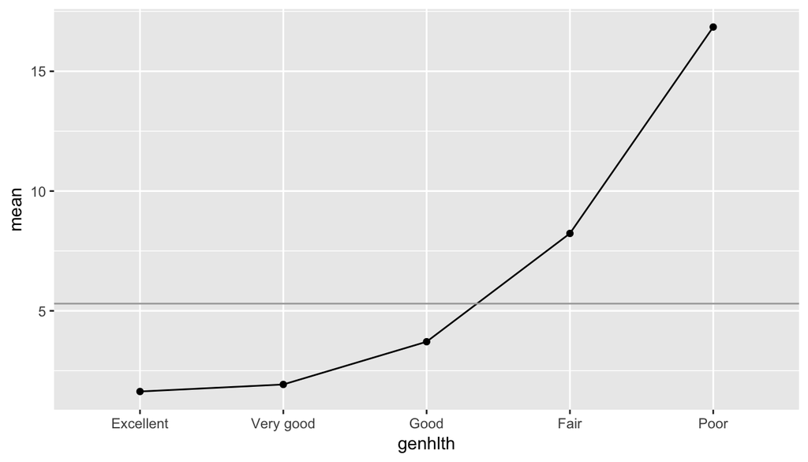

```r
ggplot(data = poorhlth_genhlth_mean, aes(x = genhlth, y = mean, group = 1)) + geom_point() + geom_line() + geom_hline(yintercept = poorhlth_mean$mu, color = "darkgray")
```

Here, we use Poor Physical Or Mental Health Days represent health status. More Poor Physical Or Mental Health Days, worse health status.

We can see that people who have better health status, have less Poor Physical Or Mental Health Days. And the mean of Poor Physical Or Mental Health Days is between “Good” and “Fair” health status.

**Research quesion 2:**

```r
poorhlth_age_sex <- brfss2013 %>% filter(!is.na(X_ageg5yr), !is.na(sex)) %>% group_by(X_ageg5yr, sex) %>% summarise(mean = mean(poorhlth, na.rm = TRUE))
poorhlth_age_sex
```

```
## # A tibble: 26 x 3
## # Groups:   X_ageg5yr [?]
##       X_ageg5yr    sex     mean
##          <fctr> <fctr>    <dbl>
##  1 Age 18 to 24   Male 2.212543
##  2 Age 18 to 24 Female 2.532348
##  3 Age 25 to 29   Male 2.701998
##  4 Age 25 to 29 Female 3.079148
##  5 Age 30 to 34   Male 3.018626
##  6 Age 30 to 34 Female 3.461963
##  7 Age 35 to 39   Male 3.688283
##  8 Age 35 to 39 Female 3.813767
##  9 Age 40 to 44   Male 4.367450
## 10 Age 40 to 44 Female 4.576728
## # ... with 16 more rows
```

We group poeple by different ages and genders, and calculate the mean of Poor Physical Or Mental Health Days.

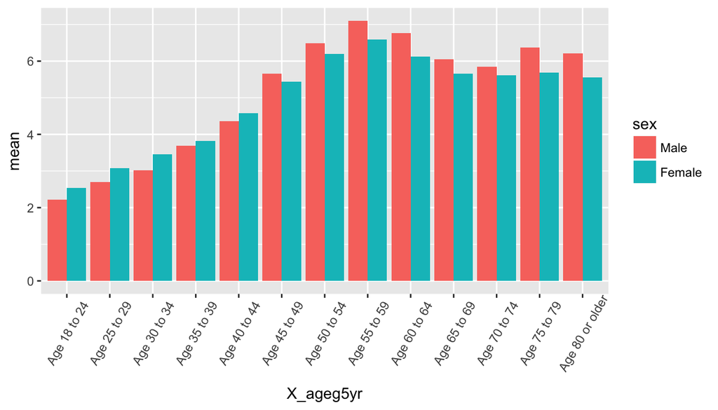

```r
ggplot(poorhlth_age_sex, aes(fill=sex, y=mean, x=X_ageg5yr)) +
    geom_bar(position="dodge", stat="identity") +   theme(axis.text.x = element_text(angle=60, vjust=0.6))
```

Here, we use Poor Physical Or Mental Health Days represent health status. More Poor Physical Or Mental Health Days, worse health status.

We can see that the Days of Poor Physical Or Mental Health is increasing between age 18 to 59. And after a little decrease, there is no obvious change. There is a little bit different between male and female, but I can’t make a conclusion.

**Research quesion 3:**

```r
age_sleptim_poorhlth <- brfss2013 %>% filter(!is.na(X_ageg5yr)) %>% group_by(X_ageg5yr) %>% summarise(mean_sleptim1 = mean(sleptim1, na.rm = TRUE), mean_poorhlth = mean(poorhlth, na.rm = TRUE))
age_sleptim_poorhlth
```

```
## # A tibble: 13 x 3
##          X_ageg5yr mean_sleptim1 mean_poorhlth
##             <fctr>         <dbl>         <dbl>
##  1    Age 18 to 24      7.114267      2.385804
##  2    Age 25 to 29      6.926006      2.918577
##  3    Age 30 to 34      6.858555      3.288880
##  4    Age 35 to 39      6.854991      3.767283
##  5    Age 40 to 44      6.851067      4.496839
##  6    Age 45 to 49      6.834425      5.523687
##  7    Age 50 to 54      6.857982      6.306606
##  8    Age 55 to 59      6.910722      6.780128
##  9    Age 60 to 64      7.051799      6.356306
## 10    Age 65 to 69      7.199115      5.799459
## 11    Age 70 to 74      7.293738      5.694410
## 12    Age 75 to 79      7.332969      5.907207
## 13 Age 80 or older      7.482060      5.753378
```

We group poeple by different ages, and calculate the mean of sleep time and Poor Physical Or Mental Health Days.

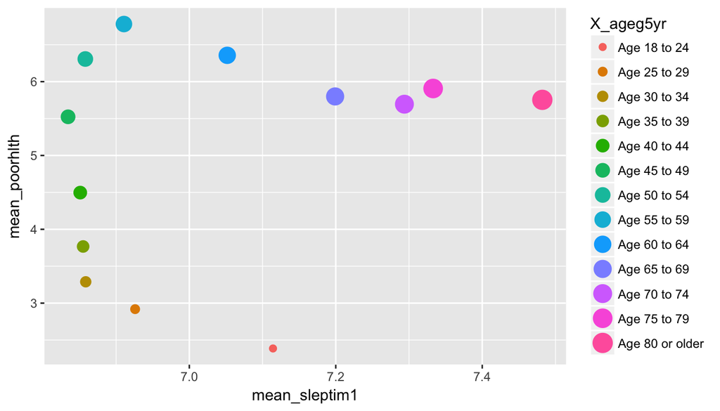

```r
ggplot(age_sleptim_poorhlth, aes(x=mean_sleptim1, y=mean_poorhlth, color=X_ageg5yr, size=X_ageg5yr)) + geom_point()
```

Here, we use Poor Physical Or Mental Health Days represent health status. More Poor Physical Or Mental Health Days, worse health status.

We can see that,

- at age 18 to 34, sleep time decrease, Poor Physical Or Mental Health Days increase,
- at age 35 to 54, sleep time no obvious change, Poor Physical Or Mental Health Days increase,
- at age 55 to 69, sleep time increase, Poor Physical Or Mental Health Days decrease,
- at age 70 to 80 or older, sleep time increase, Poor Physical Or Mental Health Days no obvious change.